# Modèles VAR

```r
roots=roots(varest9)
roots # présence de racines unitaires !!!
```

```
## [1] 0.9983275 0.3261254
```

```r
varest9$varresult
```

```
## $y1
##
## Call:
## lm(formula = y ~ -1 + ., data = datamat)
##
## Coefficients:
##  y1.l1   y2.l1
##  3.790  -6.975
##
##
## $y2
##
## Call:
## lm(formula = y ~ -1 + ., data = datamat)
##
## Coefficients:
##  y1.l1   y2.l1
##  1.386  -2.465
```

```r
R=matrix(c(3.787,-6.967,1.374,-2.435),2,2,byrow=TRUE)
YT=vdat9.train[450,]
R%*%(R%*%YT)
```

```
##           [,1]
## [1,] -70.28030
## [2,] -28.24442
```

```r
summary(ur.df(vdat9[,1],type="none",lags=1))  # non stationnaire
```

```
##
## ###############################################
## # Augmented Dickey-Fuller Test Unit Root Test #
## ###############################################
##
## Test regression none
##
##
## Call:
## lm(formula = z.diff ~ z.lag.1 - 1 + z.diff.lag)
##
## Residuals:
##     Min      1Q  Median      3Q     Max
## -22.124  -4.658  -0.440   4.375  18.171
##
## Coefficients:
##              Estimate Std. Error t value Pr(>|t|)
## z.lag.1    -0.0009015  0.0017859  -0.505    0.614
## z.diff.lag  0.3710286  0.0417172   8.894   <2e-16 ***
## ---
## Signif. codes:  0 '***' 0.001 '**' 0.01 '*' 0.05 '.' 0.1 ' ' 1
##
## Residual standard error: 6.969 on 496 degrees of freedom
## Multiple R-squared:  0.1376, Adjusted R-squared:  0.1341
## F-statistic: 39.57 on 2 and 496 DF,  p-value: < 2.2e-16
##
##
## Value of test-statistic is: -0.5048
##
## Critical values for test statistics:
##       1pct  5pct 10pct
## tau1 -2.58 -1.95 -1.62
```

```r
summary(ur.df(vdat9[,2],type="none",lags=1))  # non stationnaire
```

```
##
## ###############################################
## # Augmented Dickey-Fuller Test Unit Root Test #
## ###############################################
##
## Test regression none
##
##
## Call:
## lm(formula = z.diff ~ z.lag.1 - 1 + z.diff.lag)
##
## Residuals:
##     Min      1Q  Median      3Q     Max
## -12.496  -2.625  -0.311   2.369  10.956
##
## Coefficients:
##             Estimate Std. Error t value Pr(>|t|)
## z.lag.1    -0.001140   0.002431  -0.469   0.6392
## z.diff.lag  0.093622   0.044713   2.094   0.0368 *
## ---
## Signif. codes:  0 '***' 0.001 '**' 0.01 '*' 0.05 '.' 0.1 ' ' 1
##
## Residual standard error: 3.795 on 496 degrees of freedom
## Multiple R-squared:  0.009067,   Adjusted R-squared:  0.005071
## F-statistic: 2.269 on 2 and 496 DF,  p-value: 0.1045
##
##
## Value of test-statistic is: -0.4691
##
## Critical values for test statistics:
##       1pct  5pct 10pct
## tau1 -2.58 -1.95 -1.62
```

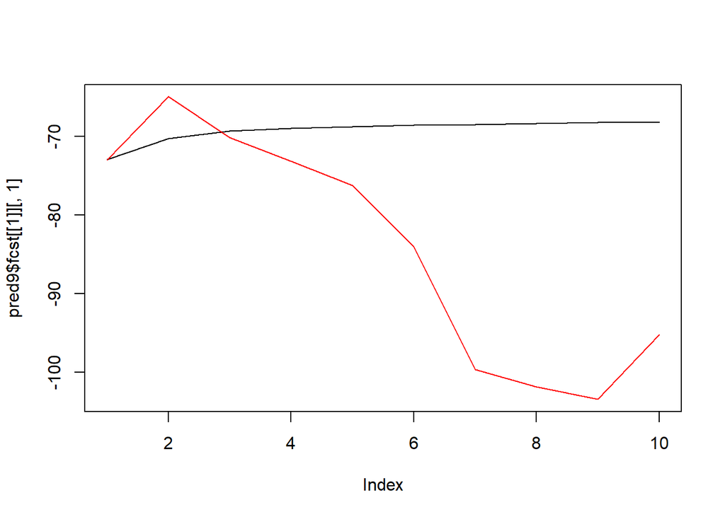

```r
# prediction
h=10
vdat9.test=vdat9[451:(450+h),]
pred9 = predict(varest9,n.ahead =h ,ci = 0.95)

plot(pred9$fcst[[1]][,1],type="l",ylim=c(min(vdat9.test[,1]),max(vdat9.test[,1])))
lines(vdat9.test[,1],col="red")
```

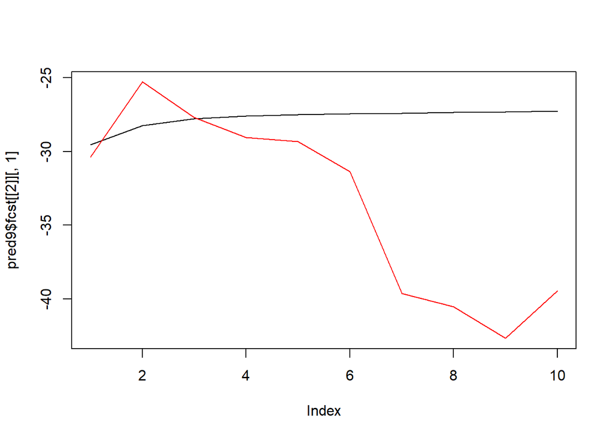

```r
plot(pred9$fcst[[2]][,1],type="l",ylim=c(min(vdat9.test[,2]),max(vdat9.test[,2])))
lines(vdat9.test[,2],col="red")
```

```r
var.test9= serial.test(varest9,lags.pt =5,type ="PT.asymptotic")
var.test9
```

```
##
##  Portmanteau Test (asymptotic)
##
## data:  Residuals of VAR object varest9
## Chi-squared = 9.9994, df = 16, p-value = 0.8667
```

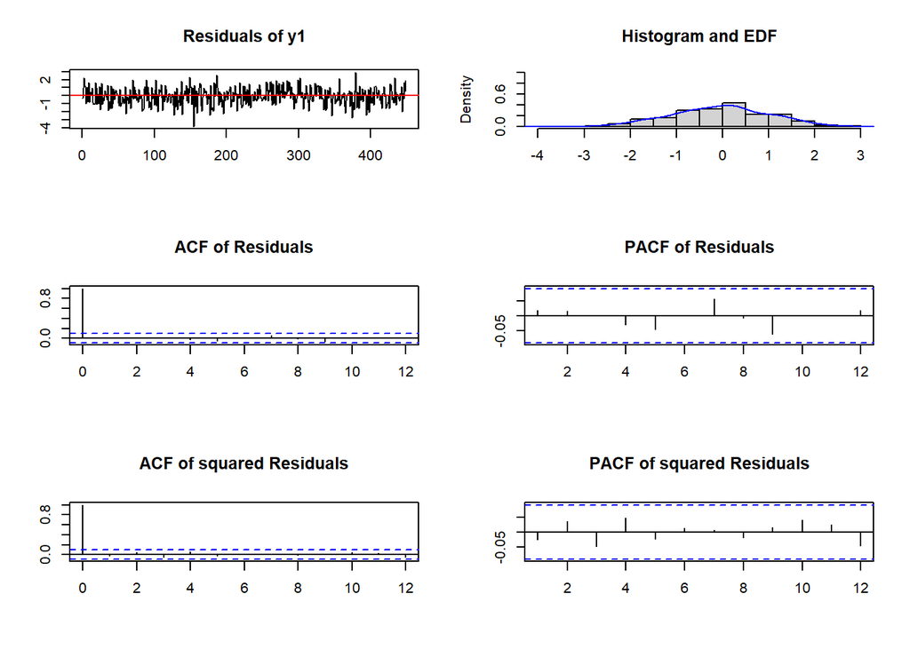

```r
plot(var.test9,names="y1")
```

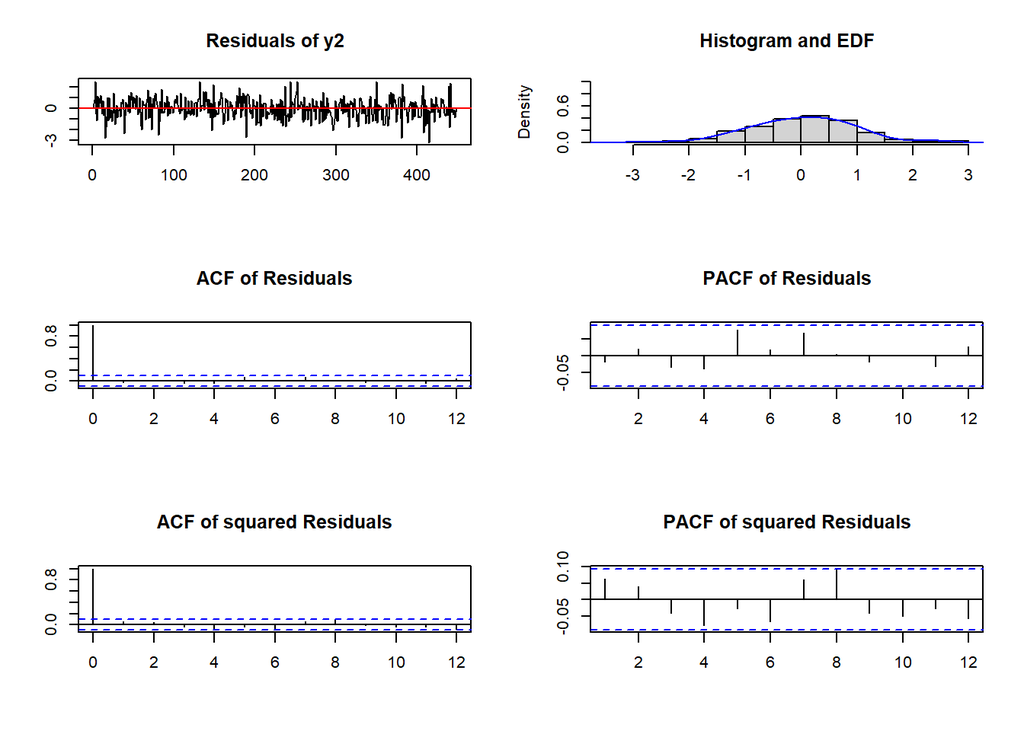

```r
plot(var.test9,names="y2")
```

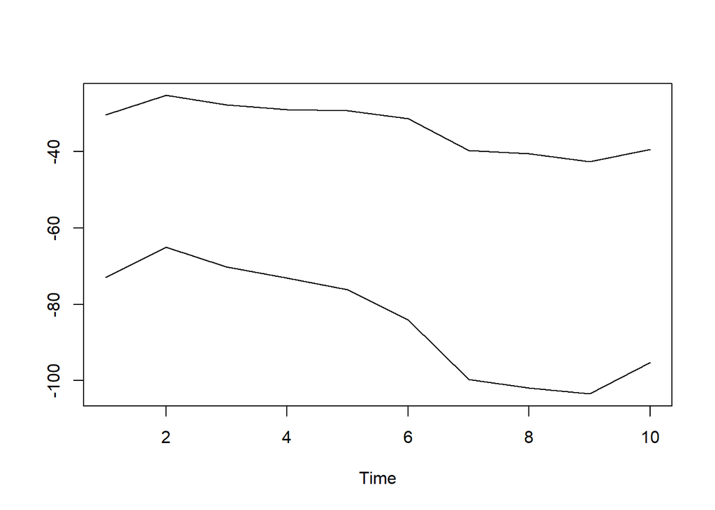

```r
ts.plot((vdat9[451:460,]))
```

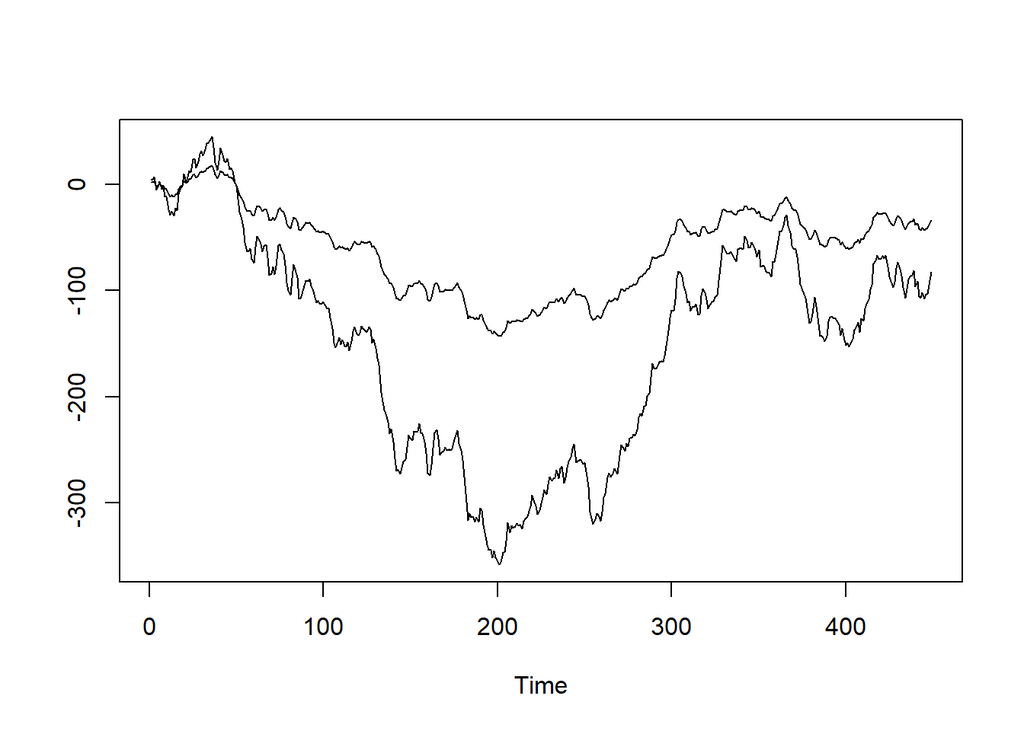

```r
ts.plot(fitted.values(varest9))
```

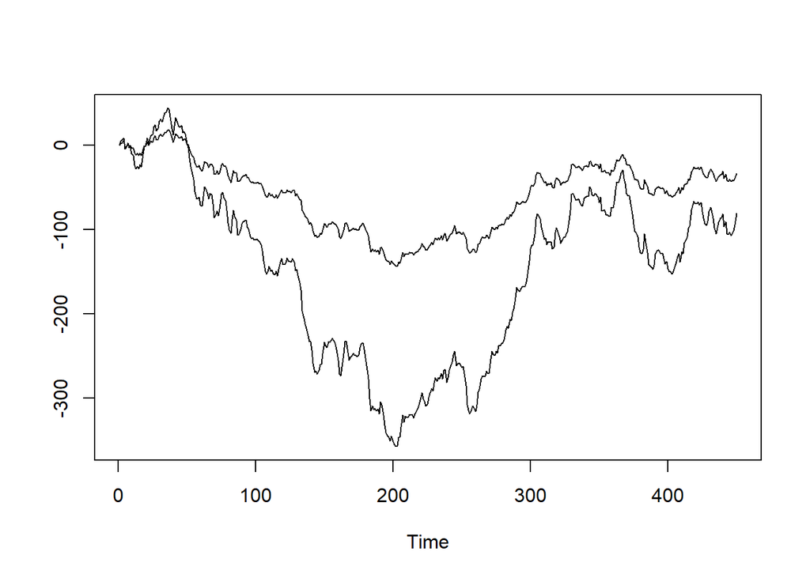

```r
ts.plot(vdat9.train)
```

```r
test=ca.jo(vdat9.train, type="trace", K=3, ecdet="none", spec="longrun")
summary(test)
```

```
##
## ######################
## # Johansen-Procedure #
## ######################
##
## Test type: trace statistic , with linear trend
##
## Eigenvalues (lambda):
## [1] 0.335004459 0.005219435
##
## Values of teststatistic and critical values of test:
##
##            test 10pct  5pct  1pct
## r <= 1 |   2.34  6.50  8.18 11.65
## r = 0  | 184.70 15.66 17.95 23.52
##
## Eigenvectors, normalised to first column:
## (These are the cointegration relations)
##
##           y1.l3     y2.l3
## y1.l3  1.000000  1.000000
## y2.l3 -2.500694 -2.124444
##
## Weights W:
## (This is the loading matrix)
##
##         y1.l3        y2.l3
## y1.d 2.727690 -0.002379622
## y2.d 1.498392  0.003737535
```

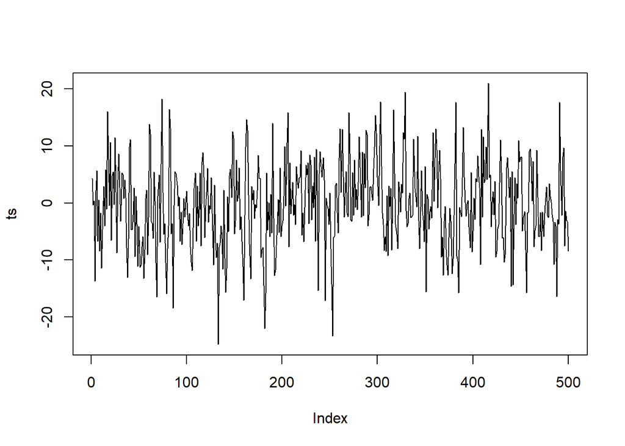

```r
ts=2.8*vdat9[,1]-7*vdat9[,2]  # le lambda(t)
plot(ts,type="l")
```

```r
library(tsDyn)
model9=VECM(vdat9.train,lag=1)
VECM.predict9=predict(model9,n.ahead=h)
VECM.predict9
```

```
##            y1        y2
## 451 -72.78033 -29.55870
## 452 -69.54351 -27.97853
## 453 -68.32176 -27.37365
## 454 -67.92017 -27.16580
## 455 -67.85187 -27.11931
## 456 -67.91904 -27.13840
## 457 -68.04127 -27.18415
## 458 -68.18587 -27.24072
## 459 -68.33957 -27.30170
## 460 -68.49697 -27.36447
```

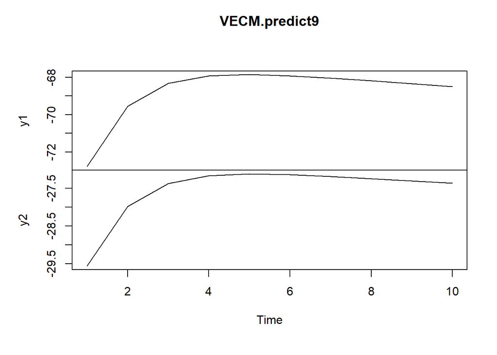

```r
plot.ts(VECM.predict9)
```

# TROISIEME PARTIE

## Application sur 5 séries temporelles.

Nous tenterons d’appliquer le modèle VAR sur l’évolution des actions Total et Engie, du Cac_40, du cours du pétrole Brent (pétrole de la Mer du Nord) et de taux de change euro-dollar sur une année, en données journalières (septembre 2019 à septembre 2020). Du fait de l’épidémie surgie en début 2020 une rupture importante se produit début avril. L’étude commencera donc à cette période (2020-03-25).

```
##         Date  Total  Engie  Cac_40 Taux_Change Brent
## 1 2019-09-12 46.580 13.940 5642.86      1.0963 60.35
## 2 2019-09-13 46.650 13.670 5655.46      1.1096 60.17
## 3 2019-09-16 47.815 13.615 5602.23      1.1031 67.78
## 4 2019-09-17 47.855 13.950 5615.51      1.1026 64.04
## 5 2019-09-18 48.020 14.160 5620.65      1.1053 63.66
## 6 2019-09-19 48.165 14.270 5659.08      1.1067 64.85
```

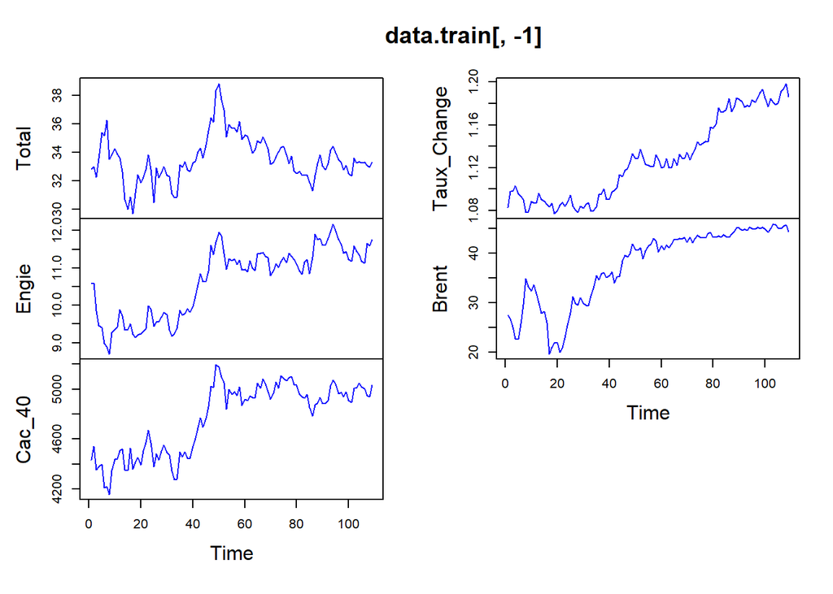

Les 4 dernières séries ne sont certainement pas stationnaires, ce que confirment les test de Dickey-Fuller. La première variable “Total” mérite un traitement à part, elle ne présente pas de trend évident, donc nous lui soumettrons le modèle “drift”.

```r
print("Total")
```

```
## [1] "Total"
```

```r
print(summary(ur.df(data.train.CR$Total,type="drift",lag=1)))
```

```
##
## ###############################################
## # Augmented Dickey-Fuller Test Unit Root Test #
## ###############################################
##
## Test regression drift
##
##
## Call:
## lm(formula = z.diff ~ z.lag.1 + 1 + z.diff.lag)
##
## Residuals:
##      Min       1Q   Median       3Q      Max
## -1.54134 -0.27742 -0.00881  0.25079  1.59445
##
## Coefficients:
##              Estimate Std. Error t value Pr(>|t|)
## (Intercept)  0.002491   0.050696   0.049  0.96091
## z.lag.1     -0.140554   0.052413  -2.682  0.00852 **
## z.diff.lag  -0.020430   0.098054  -0.208  0.83536
## ---
## Signif. codes:  0 '***' 0.001 '**' 0.01 '*' 0.05 '.' 0.1 ' ' 1
##
## Residual standard error: 0.5244 on 104 degrees of freedom
## Multiple R-squared:  0.07234,    Adjusted R-squared:  0.0545
## F-statistic: 4.055 on 2 and 104 DF,  p-value: 0.02015
##
##
## Value of test-statistic is: -2.6816 3.5962
##
## Critical values for test statistics:
##       1pct  5pct 10pct
## tau2 -3.46 -2.88 -2.57
## phi1  6.52  4.63  3.81
```

```r
for(i in c("Engie","Cac_40" ,"Taux_Change","Brent"))
{ print(i)
  print(summary(ur.df(data.train.CR[,i],type="trend",lag=2)))
}
```

```
## [1] "Engie"
##
## ###############################################
## # Augmented Dickey-Fuller Test Unit Root Test #
## ###############################################
##
## Test regression trend
##
##
## Call:
## lm(formula = z.diff ~ z.lag.1 + 1 + tt + z.diff.lag)
##
## Residuals:
##      Min       1Q   Median       3Q      Max
## -0.49391 -0.16990 -0.03046  0.13192  0.79839
##
## Coefficients:
##              Estimate Std. Error t value Pr(>|t|)
## (Intercept) -0.233897   0.099255  -2.357  0.02038 *
## z.lag.1     -0.154505   0.053537  -2.886  0.00477 **
## tt           0.004527   0.001713   2.642  0.00955 **
## z.diff.lag1  0.108637   0.093291   1.164  0.24697
## z.diff.lag2 -0.060109   0.093916  -0.640  0.52360
## ---
## Signif. codes:  0 '***' 0.001 '**' 0.01 '*' 0.05 '.' 0.1 ' ' 1
##
## Residual standard error: 0.2635 on 101 degrees of freedom
## Multiple R-squared:  0.09405,    Adjusted R-squared:  0.05817
## F-statistic: 2.621 on 4 and 101 DF,  p-value: 0.03921
##
##
## Value of test-statistic is: -2.8859 3.0038 4.1974
##
## Critical values for test statistics:
##       1pct  5pct 10pct
## tau3 -3.99 -3.43 -3.13
## phi2  6.22  4.75  4.07
## phi3  8.43  6.49  5.47
##
## [1] "Cac_40"
```

[output cut: 100 more lines]

```
## ---
## Signif. codes:  0 '***' 0.001 '**' 0.01 '*' 0.05 '.' 0.1 ' ' 1
##
## Residual standard error: 0.1881 on 101 degrees of freedom
## Multiple R-squared:  0.09125,    Adjusted R-squared:  0.05526
## F-statistic: 2.535 on 4 and 101 DF,  p-value: 0.04469
##
##
## Value of test-statistic is: -2.4611 2.567 3.2464
##
## Critical values for test statistics:
##       1pct  5pct 10pct
## tau3 -3.99 -3.43 -3.13
## phi2  6.22  4.75  4.07
## phi3  8.43  6.49  5.47
```

Nous allons différencier les variables ( $\Delta X_{t}=X_{t}- X_{t-1}$), et tenter un modèle VAR sur ces nouvelles variables (“D.Total”,“D.Engie”,“D.Cac_40” ,“D.Taux_Change”,"D.Brent) , après avoir vérifié leur stationnarité.

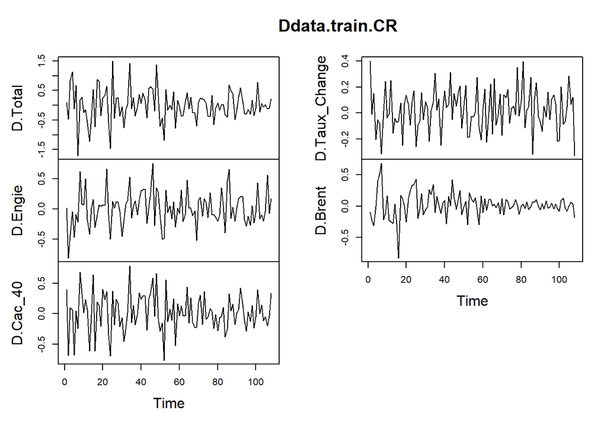

```r
Ddata.train.CR=apply(data.train.CR[,-1],2,diff)
colnames(Ddata.train.CR)=c("D.Total","D.Engie","D.Cac_40" ,"D.Taux_Change","D.Brent")

for(i in c("D.Total","D.Engie","D.Cac_40" ,"D.Taux_Change","D.Brent")) {
    print(i)
    print(summary(ur.df(Ddata.train.CR[,i],type="none",lag=1)))
}
plot.ts(Ddata.train.CR)
```

A ce stade nous devons examiner la cointégration des séries.

```r
test=ca.jo(data.train.CR[,c(-1)], type="trace", K=3, ecdet="none", spec="longrun")
summary(test)
```

```
##
## ######################
## # Johansen-Procedure #
## ######################
##
## Test type: trace statistic , with linear trend
##
## Eigenvalues (lambda):
## [1] 0.21729524 0.17483249 0.08871997 0.05648258 0.00596702
##
## Values of teststatistic and critical values of test:
##
##           test 10pct  5pct  1pct
## r <= 4 |  0.63  6.50  8.18 11.65
## r <= 3 |  6.80 15.66 17.95 23.52
## r <= 2 | 16.65 28.71 31.52 37.22
## r <= 1 | 37.02 45.23 48.28 55.43
## r = 0  | 62.99 66.49 70.60 78.87
##
## Eigenvectors, normalised to first column:
## (These are the cointegration relations)
##
##                  Total.l3   Engie.l3 Cac_40.l3 Taux_Change.l3  Brent.l3
## Total.l3        1.0000000  1.0000000  1.000000        1.00000  1.000000
## Engie.l3       -4.5670609  0.6805911  1.774829       38.03824  0.955823
## Cac_40.l3       2.0114783 -0.7066441 -6.014858       13.65332 -2.021160
## Taux_Change.l3  1.5041731  0.7587850 -1.331294      -61.76474  3.863656
## Brent.l3        0.9052651 -1.3986869  4.584279       28.16805 -1.011250
##
## Weights W:
## (This is the loading matrix)
##
##                  Total.l3    Engie.l3    Cac_40.l3 Taux_Change.l3     Brent.l3
## Total.d       -0.15167042 -0.07289481  0.016664833  -0.0013851234 -0.009069612
## Engie.d        0.02572509 -0.07558500  0.013191407  -0.0008587838 -0.003582508
## Cac_40.d      -0.03931821 -0.04323995  0.026022098  -0.0004373593 -0.004362147
## Taux_Change.d -0.00231034 -0.03363647 -0.002910155   0.0006649881 -0.001611592
## Brent.d        0.01826656  0.04302181 -0.001406270  -0.0001649348 -0.004404482
```

Il apparaît qu’avec 5 variables r=0 n’est pas rejeté

## Modèle VAR sur les cinq variables

### recherche d’un décalage adapté.

```r
Def=Ddata.train.CR
lag=lags.select(Def,lag.max =4,include="none")
print(lag)
```

```
## Best AIC:  lag= 1
## Best BIC:  lag= 1
## Best HQ :  lag= 1
```

Nous retenons un VAR(1).

## Estimation du modèle, racines unitaires et test sur les résidus, y compris sur leur normalité par le test de Jarque-Bera

```r
varModel= VAR(Def,p = 1,type ="none",season = NULL,exogen = NULL)
print(varModel)
```

```
##
## VAR Estimation Results:
## =======================
##
## Estimated coefficients for equation D.Total:
## ============================================
## Call:
## D.Total = D.Total.l1 + D.Engie.l1 + D.Cac_40.l1 + D.Taux_Change.l1 + D.Brent.l1
##
##       D.Total.l1       D.Engie.l1      D.Cac_40.l1 D.Taux_Change.l1
##       0.07956259      -0.00383999      -0.34913531      -0.09704722
##       D.Brent.l1
##      -0.20258150
##
##
## Estimated coefficients for equation D.Engie:
## ============================================
## Call:
## D.Engie = D.Total.l1 + D.Engie.l1 + D.Cac_40.l1 + D.Taux_Change.l1 + D.Brent.l1
##
##       D.Total.l1       D.Engie.l1      D.Cac_40.l1 D.Taux_Change.l1
##      -0.05820030       0.10291608      -0.03008091      -0.05494021
##       D.Brent.l1
##       0.23948416
##
##
## Estimated coefficients for equation D.Cac_40:
## =============================================
## Call:
## D.Cac_40 = D.Total.l1 + D.Engie.l1 + D.Cac_40.l1 + D.Taux_Change.l1 + D.Brent.l1
##
##       D.Total.l1       D.Engie.l1      D.Cac_40.l1 D.Taux_Change.l1
##      -0.15350764       0.16479512      -0.05157004      -0.26517809
##       D.Brent.l1
##       0.11670736
##
##
## Estimated coefficients for equation D.Taux_Change:
## ==================================================
## Call:
## D.Taux_Change = D.Total.l1 + D.Engie.l1 + D.Cac_40.l1 + D.Taux_Change.l1 + D.Brent.l1
##
##       D.Total.l1       D.Engie.l1      D.Cac_40.l1 D.Taux_Change.l1
##       0.02029905       0.05054577       0.01490606      -0.14453944
##       D.Brent.l1
##      -0.04009341
##
##
## Estimated coefficients for equation D.Brent:
## ============================================
## Call:
## D.Brent = D.Total.l1 + D.Engie.l1 + D.Cac_40.l1 + D.Taux_Change.l1 + D.Brent.l1
##
##       D.Total.l1       D.Engie.l1      D.Cac_40.l1 D.Taux_Change.l1
##       0.15070690       0.12970658      -0.47725433       0.06878413
##       D.Brent.l1
##       0.20870987
```

```r
roots=roots(varModel)
roots
```

```
## [1] 0.41682901 0.41682901 0.17840871 0.17840871 0.02845795
```

```r
varModel.test= serial.test(varModel,lags.pt =16,type ="PT.asymptotic")
varModel.test
```

```
##
##  Portmanteau Test (asymptotic)
##
## data:  Residuals of VAR object varModel
## Chi-squared = 344.82, df = 375, p-value = 0.8662
```

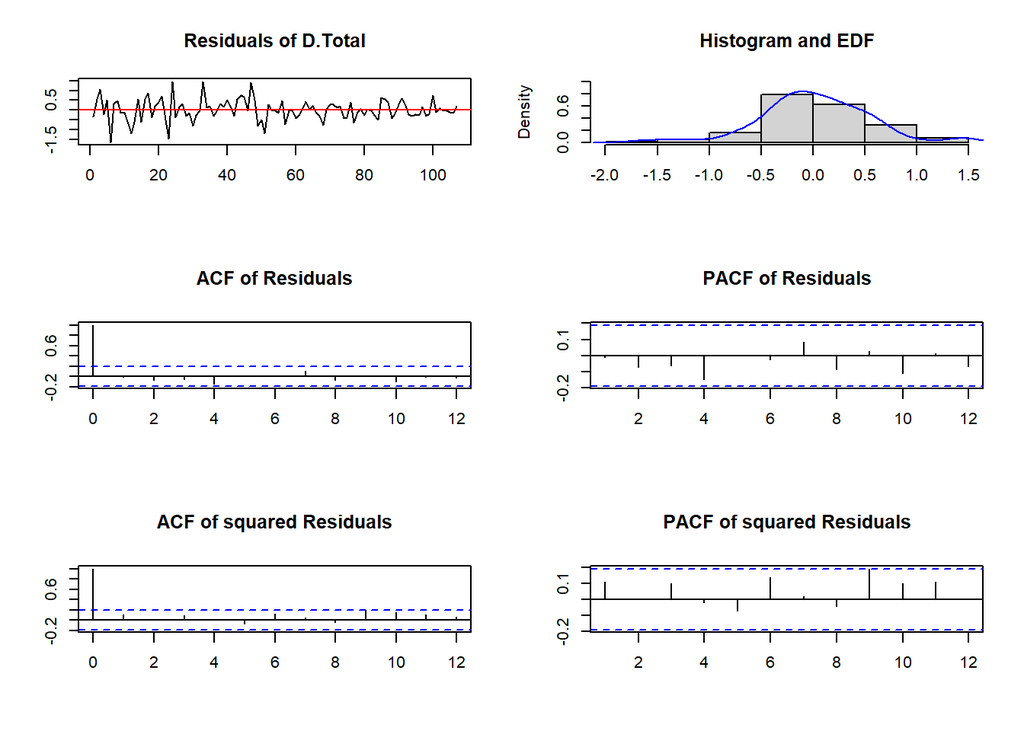

```r
plot(varModel.test,names="D.Total")
```

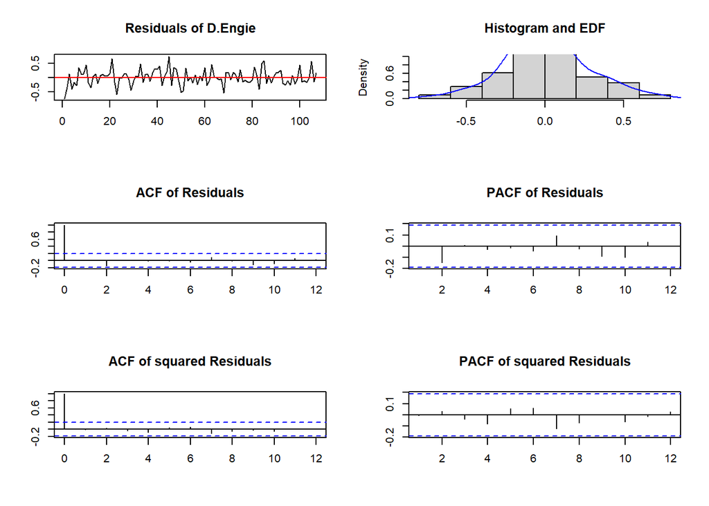

```r
plot(varModel.test,names="D.Engie")
```

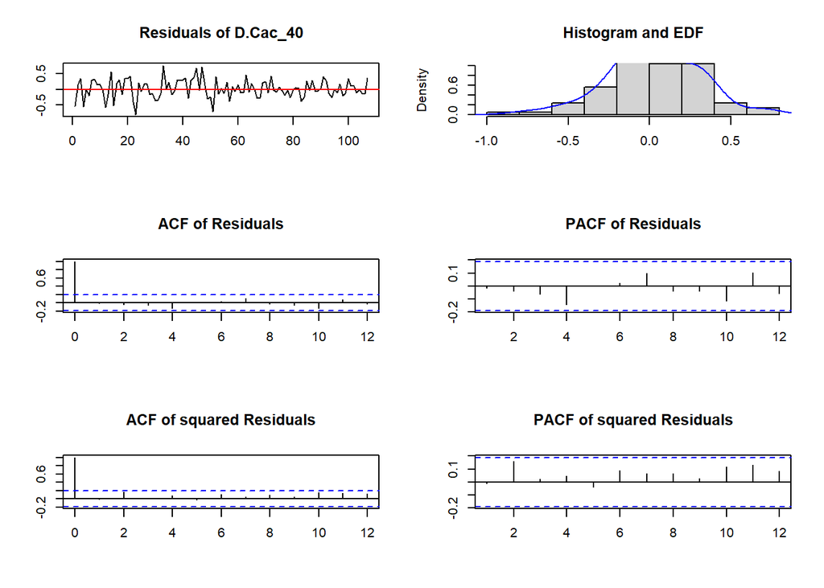

```r
plot(varModel.test,names="D.Cac_40")
```

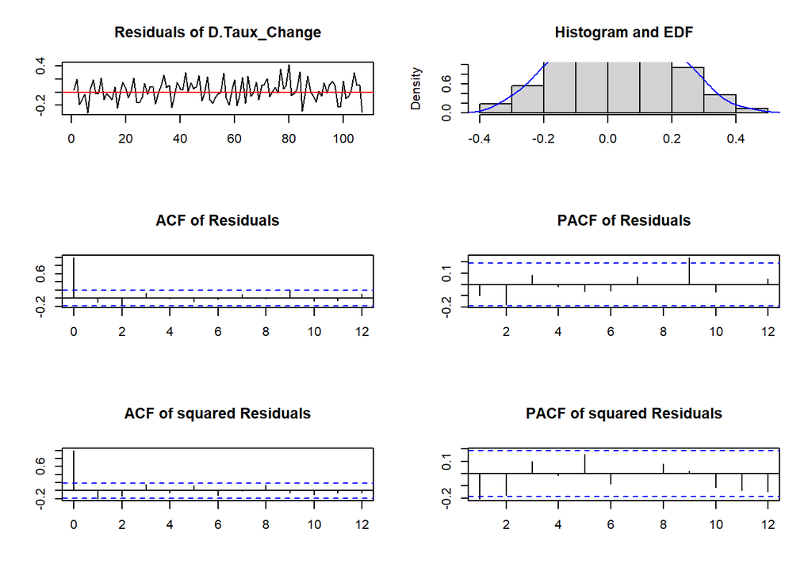

```r
plot(varModel.test,names="D.Taux_Change")
```

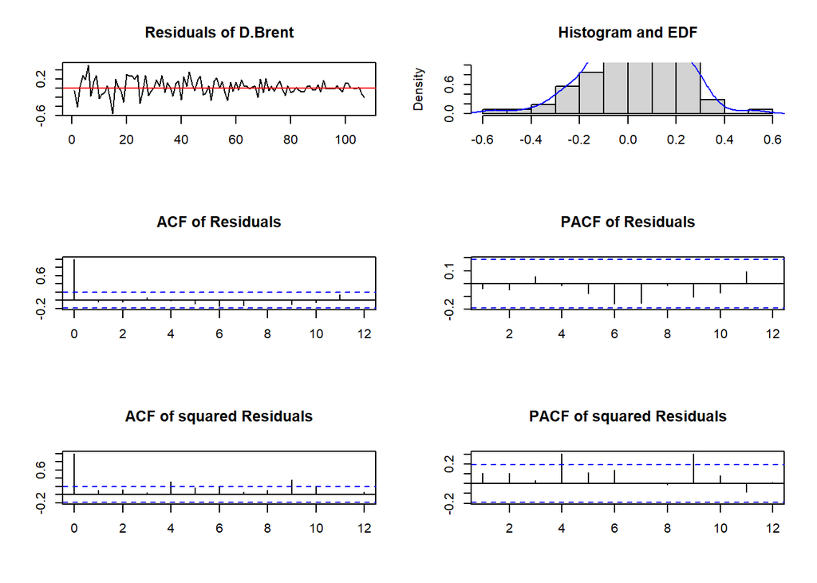

```r
plot(varModel.test,names="D.Brent")
```

```r
normality.test(varModel,multivariate.only = TRUE)
```

```
## $JB
##
##  JB-Test (multivariate)
##
## data:  Residuals of VAR object varModel
## Chi-squared = 18.965, df = 10, p-value = 0.0407
##
##
## $Skewness
##
##  Skewness only (multivariate)
##
## data:  Residuals of VAR object varModel
## Chi-squared = 1.609, df = 5, p-value = 0.9002
##
##
## $Kurtosis
##
##  Kurtosis only (multivariate)
##
## data:  Residuals of VAR object varModel
## Chi-squared = 17.356, df = 5, p-value = 0.003871
```

```r
causal.varModel=causality( varModel, cause =c("D.Cac_40","D.Taux_Change","D.Brent","D.Engie") )
causal.varModel
```

```
## $Granger
##
##  Granger causality H0: D.Engie D.Cac_40 D.Taux_Change D.Brent do not
##  Granger-cause D.Total
##
## data:  VAR object varModel
## F-Test = 0.62215, df1 = 4, df2 = 510, p-value = 0.6469
##
##
## $Instant
##
##  H0: No instantaneous causality between: D.Engie D.Cac_40 D.Taux_Change
##  D.Brent and D.Total
##
## data:  VAR object varModel
## Chi-squared = 42.616, df = 4, p-value = 1.243e-08
```

```r
causal.varModel=causality( varModel, cause =c("D.Total","D.Taux_Change") )
causal.varModel
```

```
## $Granger
##
##  Granger causality H0: D.Total D.Taux_Change do not Granger-cause
##  D.Engie D.Cac_40 D.Brent
##
## data:  VAR object varModel
## F-Test = 2.8925, df1 = 6, df2 = 510, p-value = 0.008807
##
##
## $Instant
##
##  H0: No instantaneous causality between: D.Total D.Taux_Change and
##  D.Engie D.Cac_40 D.Brent
##
## data:  VAR object varModel
## Chi-squared = 43.902, df = 6, p-value = 7.731e-08
```

```r
causal.varModel=causality( varModel, cause =c("D.Cac_40","D.Total") )
causal.varModel
```

```
## $Granger
##
##  Granger causality H0: D.Total D.Cac_40 do not Granger-cause D.Engie
##  D.Taux_Change D.Brent
##
## data:  VAR object varModel
## F-Test = 3.358, df1 = 6, df2 = 510, p-value = 0.00296
##
##
## $Instant
##
##  H0: No instantaneous causality between: D.Total D.Cac_40 and D.Engie
##  D.Taux_Change D.Brent
##
## data:  VAR object varModel
## Chi-squared = 40.539, df = 6, p-value = 3.569e-07
```

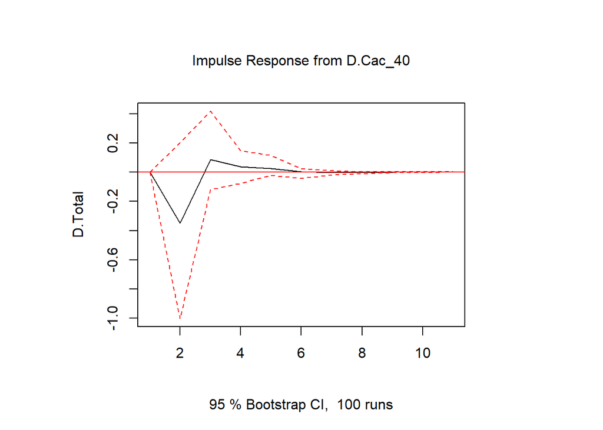

```r
imp_inst.Total=irf(varModel,impulse ="D.Cac_40",response="D.Total",n.ahead=10,ortho=FALSE,cumulative=F,boot=T,seed=12345)
plot(imp_inst.Total)
```

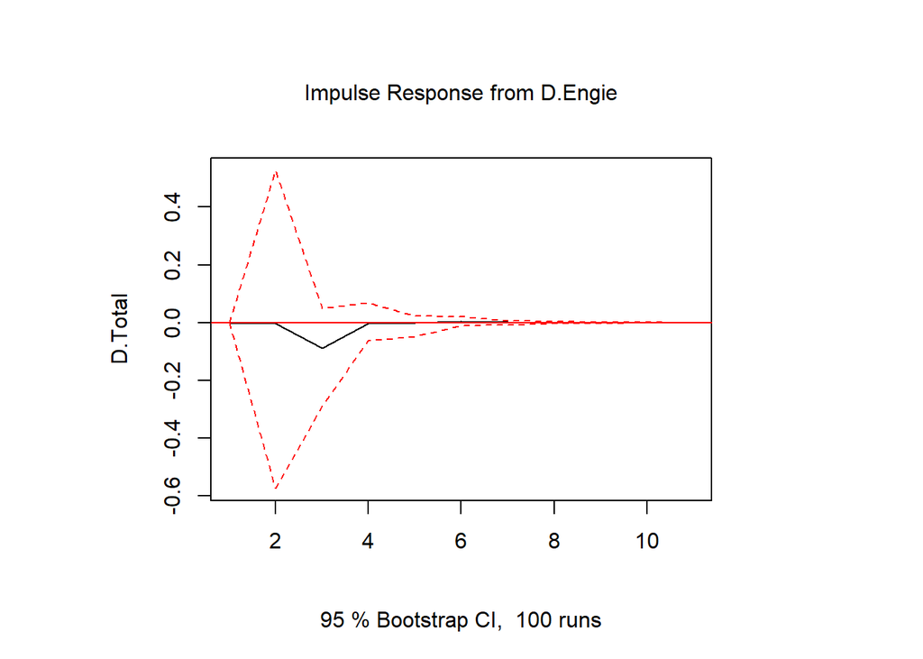

```r
imp.Total2=irf(varModel,impulse ="D.Engie",response="D.Total",n.ahead=10,ortho=FALSE,cumulative=F,boot=T,seed=12345)
plot(imp.Total2)
```

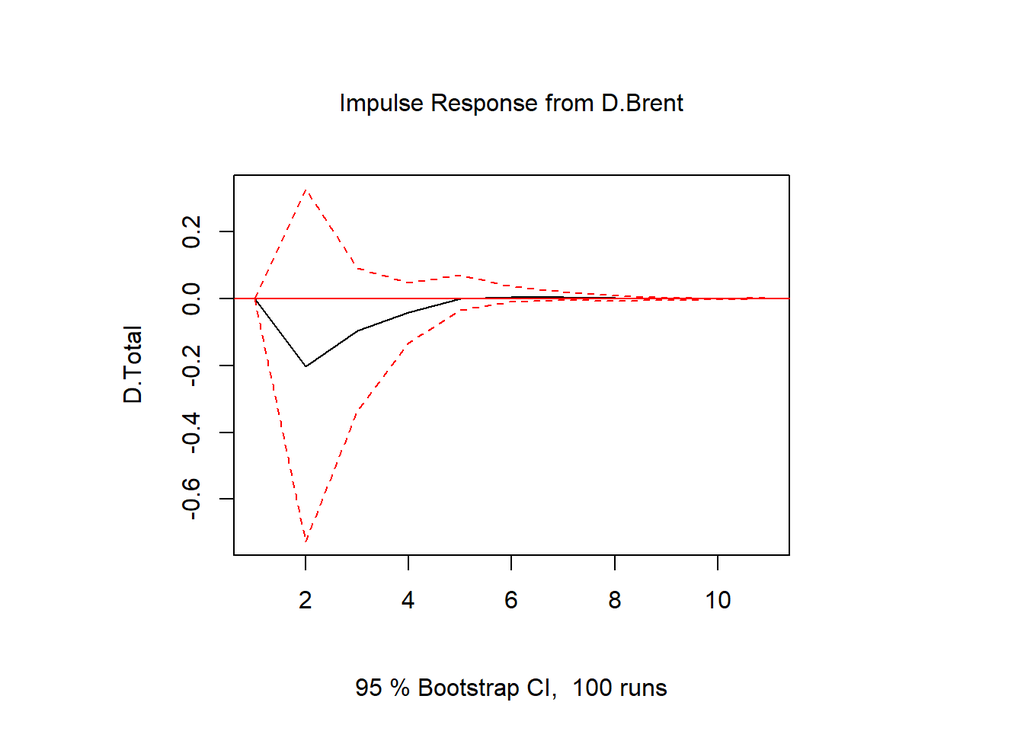

```r
imp_inst.Cac_40=irf(varModel,impulse ="D.Brent",response="D.Total",n.ahead=10,ortho=FALSE,cumulative=F,boot=T,seed=12345)
plot(imp_inst.Cac_40)
```

```r
#cor(Ddata.train$Total,Ddata.train$Cac_40)  # ????
```

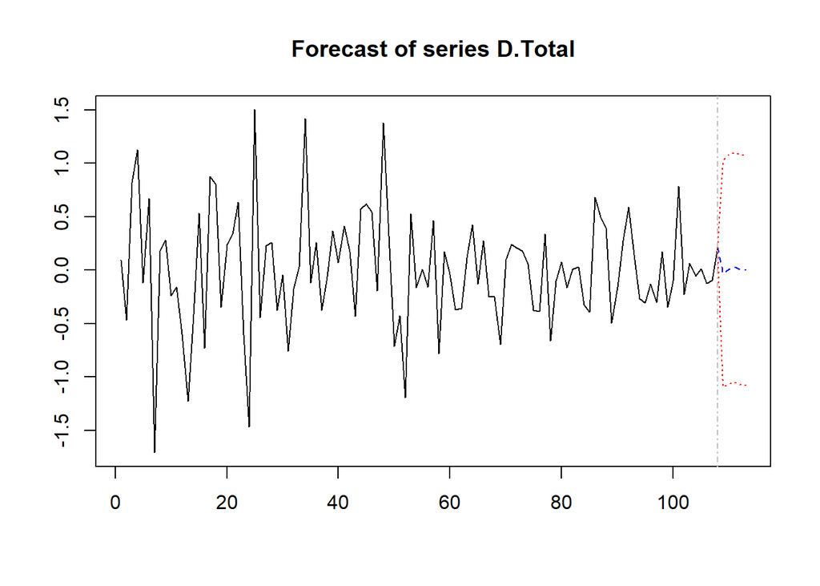

```r
p=predict(varModel,n.ahead=5)
plot(p,names="D.Total")  # prédiction dur la diff
```

```r
# Une fonction qui réintègre les valeurs différenciées de la prédiction
int.pred=function(Train,Pred ){
  #Pred=p ; Train=data.train.CR ; Name="D.Total"
  l=dim(Train)[1] ; c=dim(Train)[2]-1
  h=length(Pred$fcst[[1]][,1])
  init=Train[l,-1]
  P=matrix(0,nrow=h,ncol=c)
  for(j in 1:c) {
  P[,j]=Pred$fcst[[j]][,1]}
 P[1,]=P[1,]+as.matrix(init)
 # calcul de autre valeurs prédites par sommes cumulées des accroissements
for(i in 2:h ) {    P[i,]=P[i-1,]+P[i,] }
 P=as.data.frame(P)
P=cbind(data.test.CR[,1],P)
 colnames(P)=colnames(data.test.CR)
  return(P)
}
result=int.pred(data.train.CR,p)
print(result)
```

```
##         Date      Total    Engie    Cac_40 Taux_Change     Brent
## 1 2020-09-03 -0.1983192 1.154405 0.9902715    1.608296 0.7234528
## 2 2020-09-04 -0.1895959 1.107849 0.9490163    1.602917 0.6636868
## 3 2020-09-07 -0.1616899 1.089773 0.9365837    1.603299 0.6658083
## 4 2020-09-08 -0.1555265 1.087150 0.9301084    1.602627 0.6740720
## 5 2020-09-09 -0.1543741 1.088732 0.9302068    1.602289 0.6794294
```

```r
print(data.test.CR)
```

```
##           Date       Total    Engie    Cac_40 Taux_Change     Brent
## 245 2020-09-03 -0.21631809 1.308751 0.8662359    1.410001 0.8419136
## 246 2020-09-04 -0.36837849 1.066494 0.7072622    1.485750 0.6283075
## 247 2020-09-07  0.01022087 1.470256 1.0243154    1.438733 0.5853258
## 248 2020-09-08 -0.75008113 1.206465 0.7374833    1.336864 0.3000834
## 249 2020-09-09 -0.50802580 1.373353 0.9859042    1.305519 0.4016766
```

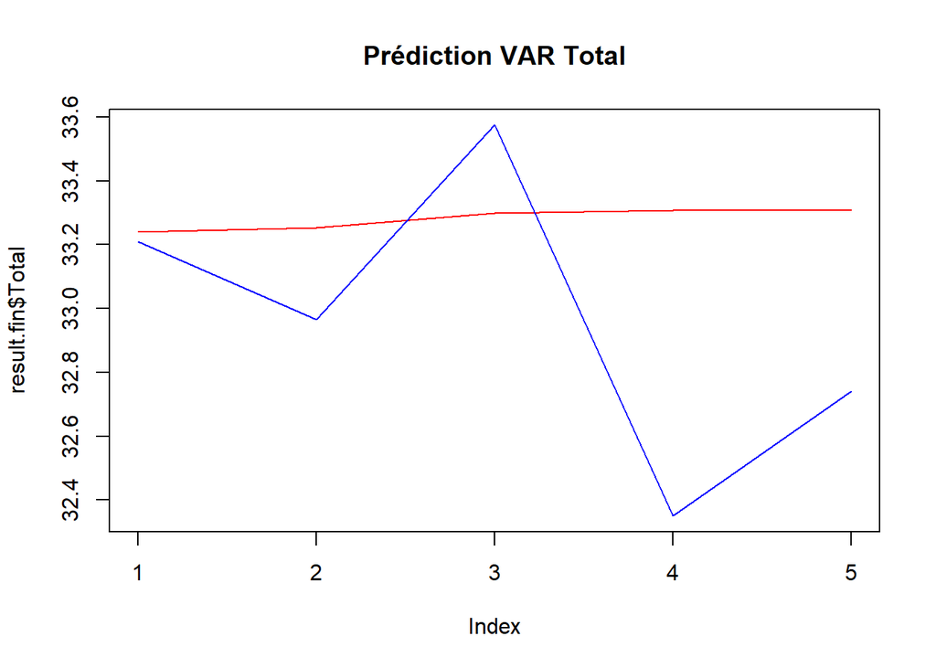

```r
# retour aux variables initiales
sigma=matrix(s,nrow=h,ncol=5,byrow=TRUE)
Mean=matrix(m,nrow=h,ncol=5,byrow=TRUE)
result.fin=as.matrix(result[,-1])*sigma+Mean
result.fin=as.data.frame(result.fin)
plot(result.fin$Total,type="l",col="red",ylim=c(min(data.test$Total),max(data.test$Total)),main="Prédiction VAR Total")
lines(data.test$Total,col="blue")
```

```r
# https://towardsdatascience.com/vector-autoregressions-vector-error-correction-multivariate-model-a69daf6ab618
library(tsDyn)
model=VECM(data.train[,-1],lag=2)
VECM.predict=predict(model,n.ahead=5)
VECM.predict
```

```
##        Total    Engie   Cac_40 Taux_Change    Brent
## 110 33.28565 11.73778 5037.637    1.188623 43.14108
## 111 33.58698 11.78115 5062.765    1.195354 43.17905
## 112 33.65846 11.79893 5043.179    1.195256 43.19112
## 113 33.74437 11.80033 5036.543    1.195954 43.46795
## 114 33.84956 11.80645 5039.350    1.196624 43.85057
```

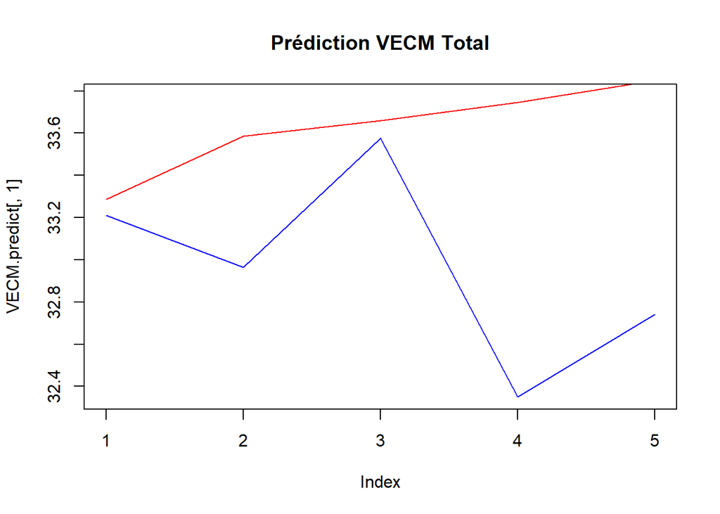

```r
plot(VECM.predict[,1],type="l",col="red",ylim=c(min(data.test$Total),max(data.test$Total)+.2),main="Prédiction VECM Total")
lines(data.test$Total,col="blue")
```